# Part II - (Car Price Prediction DataSet)

## by (Toluwalase Abikehin)

## Investigation Overview

> The goal of this investigation is to understand the key features that drives the price of a car. You want to own a car company?, there sure are certain features you need to pay attention to. We will talk about some of these.

## Dataset Overview

> > The Car Price Prediction DataSet was gotten from https://www.kaggle.com/datasets/deepcontractor/car-price-prediction-challenge/discussion/335871. The dataset presents the pricing of cars with some car features including 'Levy', 'Manufacturer', 'Model', 'Prod. year','Category', 'Leather interior', 'Fuel type', 'Engine volume', 'Mileage','Cylinders', 'Gear box type', 'Drive wheels', 'Doors', 'Wheel', 'Color','Airbags'.

## (Visualization 1)

> Mr John is considering starting up a car company, if he doesn't want to lose his money, he had better pay attention to the key car features that are dominating the market. What are these features?

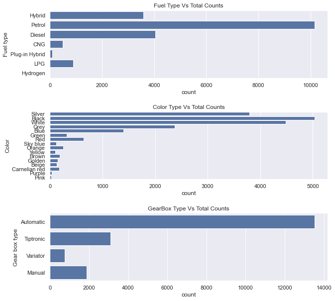

```
'Petrol fuel types, black colored cars, Automatic bear box type makes the highest car Counts.'
```

## (Visualization 2)

> You may not just want to know the car types that are dominating in terms of counts but also in terms of prize as well. Guess the features of the highest prized car:

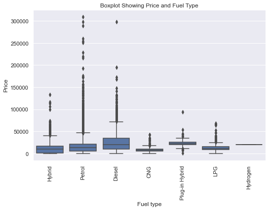

```
'The Diesel Fueled Cars are higher in price than other Fuel types'
```

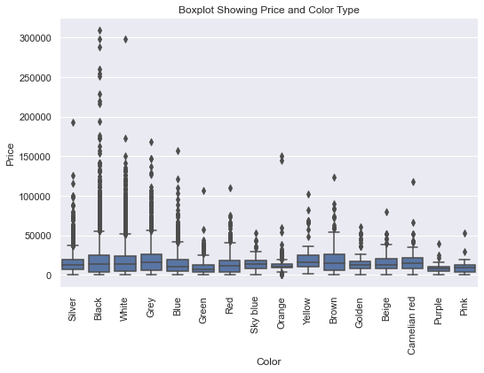

```
'Black and Grey Cars are higher in price than other Color types'
```

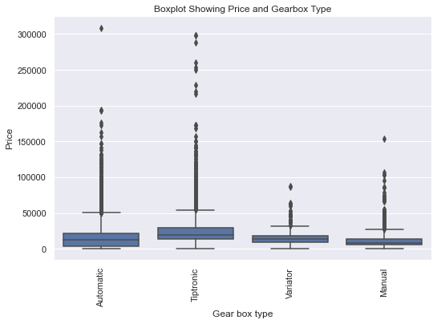

[output not shown]